# report

- Introduction
- Global Distribution: Choropleth Map
- Top 10 Countries by Average Deprivation
- Global Trend Over Time
- Gender Differences in Top 10 Countries

# **Global Child Deprivation Analysis**

This page analyzes child deprivation data from UNICEF, focusing on the percentage of children experiencing exactly one severe deprivation. We explore global trends, country-specific data, and gender differences to provide a comprehensive overview of the issue.

```python
# Install required packages
!pip install plotnine geopandas
import pandas as pd
import geopandas as gpd
from plotnine import *

# Load and prepare data
df = pd.read_csv("unicef_indicator_2.csv")
df['year'] = df['time_period'].astype(str).str[:4].astype(int)
```

# **Introduction**

Child poverty is a multidimensional phenomenon that goes beyond household income, encompassing deprivations in areas such as nutrition, health, education, and shelter. UNICEF's approach measures not just the presence of poverty, but the depth and breadth of deprivation experienced by children. Understanding where and how children are deprived is essential for designing effective policies and interventions

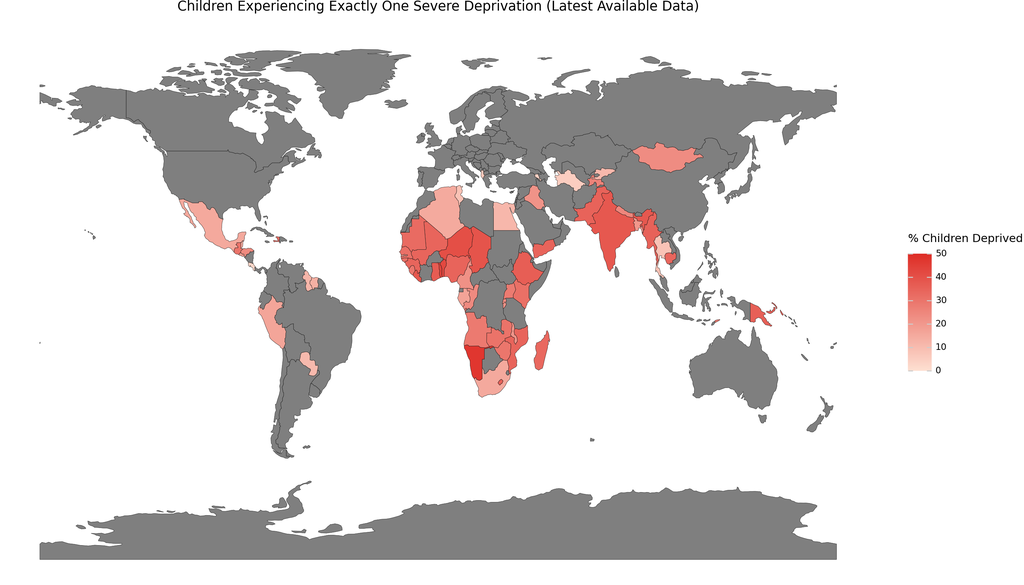

```python
# Get world map data
world = gpd.read_file("https://naciscdn.org/naturalearth/110m/cultural/ne_110m_admin_0_countries.zip")

# Ensure 'year' column exists before sorting
if 'year' not in df.columns:
    df['year'] = df['time_period'].astype(str).str[:4].astype(int)

# Prepare deprivation data (latest year per country)
latest_deprivation = df[df['sex'] == 'Total'].sort_values('year').groupby('country').tail(1)

# Merge with world map
merged = world.merge(latest_deprivation,
                    left_on='NAME',
                    right_on='country',
                    how='left')

# Create choropleth map
(ggplot(merged)
 + geom_map(aes(fill='obs_value'), size=0.15)
 + scale_fill_gradient(name="% Children Deprived",
                      low="#fee0d2",
                      high="#de2d26",
                      limits=[0, 50])
 + labs(title="Children Experiencing Exactly One Severe Deprivation (Latest Available Data)")
 + theme_void()
 + theme(figure_size=(14, 8), legend_position='right')
)
```

# **Top 10 Countries by Average Deprivation**

Next, we identify the countries with the highest average rates of child deprivation. This bar chart ranks the top 10 countries, drawing attention to where the challenge is most acute. Such rankings are crucial for global monitoring and for targeting resources to the most affected populations.

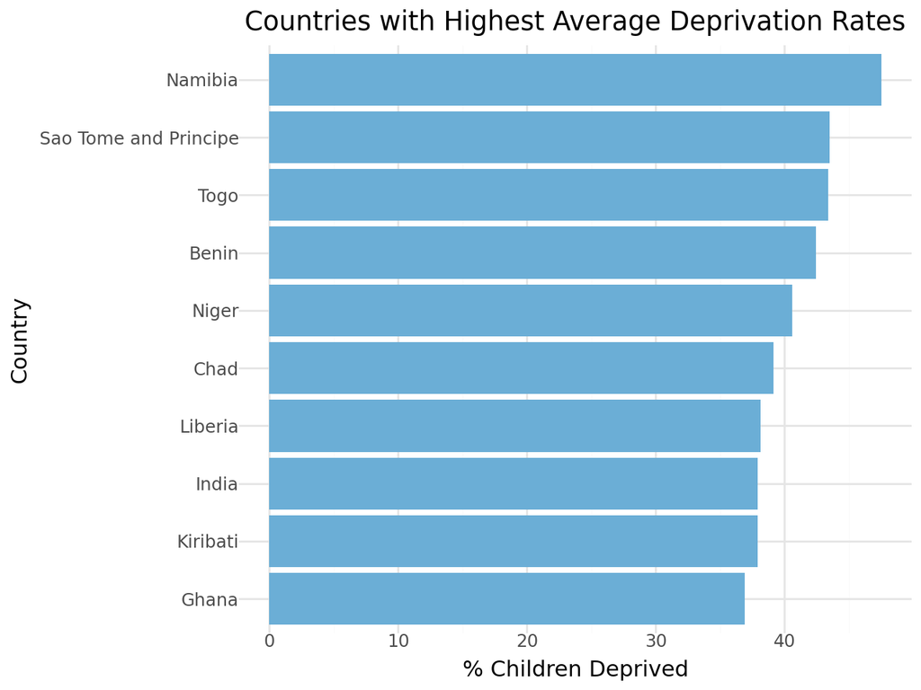

```python
top10 = (df[df['sex'] == 'Total']
         .groupby('country')['obs_value']
         .mean()
         .nlargest(10)
         .reset_index())

(ggplot(top10, aes(x='reorder(country, obs_value)', y='obs_value'))
 + geom_col(fill='#6baed6')
 + coord_flip()
 + labs(x="Country", y="% Children Deprived",
       title="Countries with Highest Average Deprivation Rates")
 + theme_minimal()
)
```

```python
# First install scikit-misc
!pip install scikit-misc --no-cache-dir

# Then restart your runtime (Runtime → Restart runtime)
```

```
Downloading scikit_misc-0.5.1-cp311-cp311-manylinux_2_17_x86_64.manylinux2014_x86_64.whl (188 kB)
   ━━━━━━━━━━━━━━━━━━━━━━━━━━━━━━━━━━━━━━━━ 0.0/189.0 kB ? eta -:--:--
   ━━━━━━━━━━━━━━━━━━━━━━━━━━━━━━━━━━━━━━━━ 189.0/189.0 kB 38.2 MB/s eta 0:00:00
```

# **Global Trend Over Time**

To understand how child deprivation has changed globally, we plot the trend over time. This graph shows whether progress has been made in reducing deprivation, and highlights any periods of stagnation or reversal-such as the impact of global crises like the COVID-19 pandemic

[figure not shown]

```python
(ggplot(df[df['sex'] == 'Total'], aes(x='year', y='obs_value'))
 + geom_point(alpha=0.3, color='#3182bd')
 + stat_smooth(method='loess', color='#de2d26')
 + labs(x="Year", y="Deprivation %",
       title="Global Trend in Child Deprivation (2000-2020)")
 + scale_x_continuous(breaks=range(2000, 2025, 5))
)
```

# **Gender Differences in Top 10 Countries**

Finally, we examine gender differences in child deprivation within the top 10 most affected countries. This comparison reveals whether boys or girls are more likely to experience deprivation, helping to inform gender-sensitive policy responses and interventions

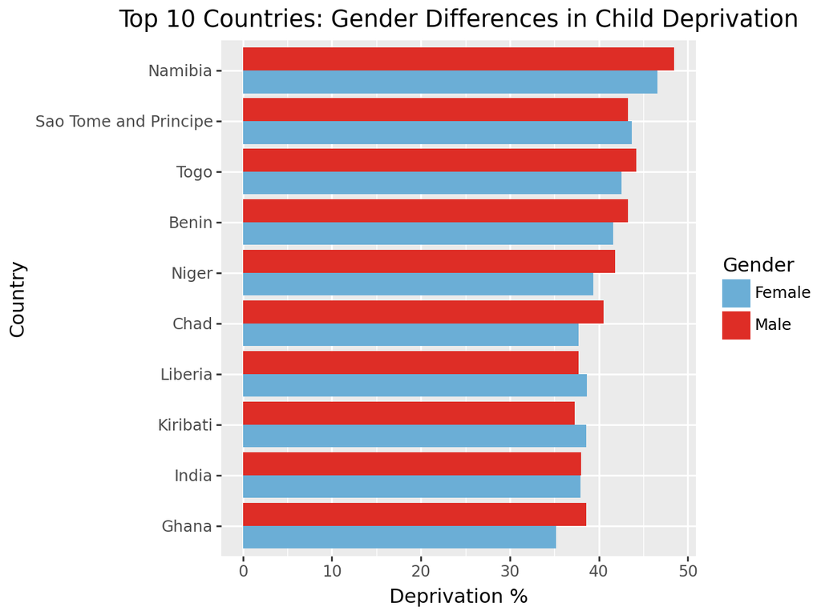

```python
import pandas as pd
from plotnine import *

# Load the data (if not already loaded)
df = pd.read_csv('unicef_indicator_2.csv')

# Filter for Male and Female only
filtered = df[df['sex'].isin(['Male', 'Female'])]

# Calculate mean deprivation by country and sex
gender_comparison = filtered.groupby(['country', 'sex'])['obs_value'].mean().reset_index()

# Calculate average deprivation by country (across both sexes)
avg_deprivation = gender_comparison.groupby('country')['obs_value'].mean().reset_index()

# Get top 10 countries by average deprivation
top10_countries = avg_deprivation.nlargest(10, 'obs_value')['country'].tolist()

# Filter gender_comparison for only top 10 countries
top10_gender_comparison = gender_comparison[gender_comparison['country'].isin(top10_countries)]

# Create the plot
plot = (
    ggplot(top10_gender_comparison, aes(x='reorder(country, obs_value)', y='obs_value', fill='sex'))
    + geom_col(position='dodge')
    + coord_flip()
    + scale_fill_manual(values=['#6baed6', '#de2d26'])
    + labs(
        x="Country",
        y="Deprivation %",
        title="Top 10 Countries: Gender Differences in Child Deprivation",
        fill="Gender"
    )
)

plot
```